# Vermont Covid-19 Project

May 1, 2025

## Step 1 - Attach Necessary Libraries

```r
library(tidyverse)
library(zoo)
library(skimr)
library(gridExtra)
library(infer)
library(moderndive)
```

## Step 2 - Loading Datasets

```r
counties <- read.csv("https://raw.githubusercontent.com/nytimes/covid-19-data/master/us-counties.csv")

poverty <- read.csv("~/Documents/GitHub Portfolio/Coivd Project/Vermont_Poverty2023.csv")

education <- read.csv("~/Documents/GitHub Portfolio/Coivd Project/Vermont_Education.csv")

unemployment <- read.csv("~/Documents/GitHub Portfolio/Coivd Project/Vermont_Unemployment.csv")

demog <- read.csv("~/Documents/GitHub Portfolio/Coivd Project/Vermont_Demographics.csv")

vax <- read.csv("~/Documents/GitHub Portfolio/Coivd Project/vaccinations.csv")

mask_use <- read.csv("~/Documents/GitHub Portfolio/Coivd Project/mask-use-by-county.csv")
```

## Step 3 - Cleaning and Combining Data

```r
vt <- counties %>%
  filter(state == "Vermont")

vt <- vt %>%
  group_by(county) %>%
  mutate(new_cases = cases - lag(cases, default = 0, order_by = date),
         new_deaths = deaths - lag(deaths, default = 0, order_by = date),
         new_cases_07_day = rollmean(new_cases, k = 7, fill = NA),
         new_deaths_07_day = rollmean(new_deaths, k = 7, fill = NA))

poverty <- poverty %>%
  mutate(county = str_trim(county))
education <- education %>%
  mutate(county = str_trim(county))
unemployment <- unemployment %>%
  mutate(county = str_trim(county))
demog <- demog %>%
  mutate(county = str_trim(county))

vt_extra <- left_join(poverty, education, by = "county") %>%
  left_join(unemployment, by = "county") %>%
  left_join(vax, by = "county") %>%
  left_join(demog, by = "county") %>%
  left_join(mask_use, by = "FIPS_Code")

vt_extra <- vt_extra %>%
  mutate(PCT_always = ALWAYS * 100)

comma_cols <- vt_extra %>%
  select(where(is.character)) %>%
  select(where(~ any(grepl(",", .)))) %>%
  names()

vt_extra <- vt_extra %>%
  mutate(across(all_of(comma_cols), ~ as.numeric(gsub(",", "", .))))

vt_cov <- left_join(vt, vt_extra, by = "county")
vt_cov <- vt_cov %>%
  mutate(cases_per_100000 = (cases / Population) * 100000,
         deaths_per_100000 = (deaths / Population) * 100000)
vt_cov <- vt_cov %>%
  filter(county != "Unknown")
vt_cov$date <- as.Date(vt_cov$date)
```

## Step 4 - Exploratory Data Analysis

### Outcome Variables

```r
glimpse(vt)
```

```
## Rows: 11,758
## Columns: 10
## Groups: county [15]
## $ date              <chr> "2020-03-07", "2020-03-08", "2020-03-09", "2020-03-1…
## $ county            <chr> "Bennington", "Bennington", "Bennington", "Benningto…
## $ state             <chr> "Vermont", "Vermont", "Vermont", "Vermont", "Vermont…
## $ fips              <int> 50003, 50003, 50003, 50003, 50003, 50007, 50003, 500…
## $ cases             <int> 1, 1, 1, 1, 1, 1, 1, 1, 1, 1, 1, 1, 1, 2, 2, 2, 1, 3…
## $ deaths            <int> 0, 0, 0, 0, 0, 0, 0, 0, 0, 0, 0, 0, 0, 0, 0, 0, 0, 0…
## $ new_cases         <int> 1, 0, 0, 0, 0, 1, 0, 0, 0, 0, 0, 0, 1, 2, 1, 1, 0, 1…
## $ new_deaths        <int> 0, 0, 0, 0, 0, 0, 0, 0, 0, 0, 0, 0, 0, 0, 0, 0, 0, 0…
## $ new_cases_07_day  <dbl> NA, NA, NA, 0.1428571, 0.0000000, NA, 0.1428571, NA,…
## $ new_deaths_07_day <dbl> NA, NA, NA, 0.0000000, 0.0000000, NA, 0.0000000, NA,…
```

```r
summary(vt)
```

```
##      date              county             state                fips
##  Length:11758       Length:11758       Length:11758       Min.   :50001
##  Class :character   Class :character   Class :character   1st Qu.:50007
##  Mode  :character   Mode  :character   Mode  :character   Median :50015
##                                                           Mean   :50014
##                                                           3rd Qu.:50021
##                                                           Max.   :50027
##                                                           NA's   :782
##      cases           deaths         new_cases           new_deaths
##  Min.   :    0   Min.   :  0.00   Min.   :-13102.00   Min.   :-16.00000
##  1st Qu.:   75   1st Qu.:  1.00   1st Qu.:     0.00   1st Qu.:  0.00000
##  Median :  803   Median :  5.00   Median :     1.00   Median :  0.00000
##  Mean   : 2145   Mean   : 16.57   Mean   :    10.93   Mean   :  0.05511
##  3rd Qu.: 2244   3rd Qu.: 20.00   3rd Qu.:     9.00   3rd Qu.:  0.00000
##  Max.   :34629   Max.   :175.00   Max.   :  3902.00   Max.   :  9.00000
##
##  new_cases_07_day     new_deaths_07_day
##  Min.   :-2075.8571   Min.   :-2.28571
##  1st Qu.:    0.2857   1st Qu.: 0.00000
##  Median :    2.8571   Median : 0.00000
##  Mean   :   10.8969   Mean   : 0.05513
##  3rd Qu.:   10.7143   3rd Qu.: 0.00000
##  Max.   :  873.2857   Max.   : 1.85714
##  NA's   :90           NA's   :90
```

### Explanatory Variables

```r
glimpse(vt_extra)
```

```
## Rows: 14
## Columns: 42
## $ FIPS_Code                            <int> 50001, 50003, 50005, 50007, 50009…
## $ county                               <chr> "Addison", "Bennington", "Caledon…
## $ Rural_Urban_Continuum_Code_2023      <int> 6, 6, 9, 3, 9, 3, 3, 8, 9, 9, 7, …
## $ Urban_Influence_Code_2024            <int> 6, 5, 8, 4, 9, 4, 4, 6, 7, 9, 7, …
## $ POVALL_2023                          <dbl> 3010, 4272, 4192, 12459, 864, 495…
## $ PCTPOVALL_2023                       <dbl> 8.7, 11.9, 14.0, 7.8, 14.4, 9.9, …
## $ MEDHHINC_2023                        <dbl> 82234, 67124, 64229, 96142, 58359…
## $ Rural_Urban                          <chr> "Rural", "Rural", "Rural", "Urban…
## $ Less_than_HS                         <dbl> 1286, 1577, 1405, 5115, 523, 2510…
## $ HS_graduate                          <dbl> 7596, 7298, 7557, 19642, 1843, 13…
## $ Some_college_or_associate_degree     <dbl> 5952, 6976, 6120, 25496, 1222, 96…
## $ Bachelor_or_higher                   <dbl> 11408, 11088, 7080, 63437, 964, 1…
## $ PCT_less_than_HS                     <dbl> 4.9, 5.9, 6.3, 4.5, 11.5, 7.0, 3.…
```

[output cut: 29 more lines]

```r
summary(vt_extra)
```

```
##    FIPS_Code        county          Rural_Urban_Continuum_Code_2023
##  Min.   :50001   Length:14          Min.   :3.000
##  1st Qu.:50008   Class :character   1st Qu.:4.500
##  Median :50014   Mode  :character   Median :7.000
##  Mean   :50014                      Mean   :6.429
##  3rd Qu.:50020                      3rd Qu.:8.750
##  Max.   :50027                      Max.   :9.000
##  Urban_Influence_Code_2024  POVALL_2023    PCTPOVALL_2023   MEDHHINC_2023
##  Min.   :4.000             Min.   :  650   Min.   : 7.800   Min.   :58359
##  1st Qu.:5.000             1st Qu.: 2891   1st Qu.: 8.925   1st Qu.:64281
##  Median :6.500             Median : 4232   Median : 9.900   Median :73291
##  Mean   :6.286             Mean   : 4399   Mean   :10.657   Mean   :73440
##  3rd Qu.:7.000             3rd Qu.: 5005   3rd Qu.:11.875   3rd Qu.:81654
##  Max.   :9.000             Max.   :12459   Max.   :14.400   Max.   :96142
##  Rural_Urban         Less_than_HS   HS_graduate
##  Length:14          Min.   : 187   Min.   : 1680
##  Class :character   1st Qu.:1229   1st Qu.: 7068
##  Mode  :character   Median :1608   Median : 7598
##                     Mean   :1809   Mean   : 9013
##                     3rd Qu.:2149   3rd Qu.:12115
##                     Max.   :5115   Max.   :19642
##  Some_college_or_associate_degree Bachelor_or_higher PCT_less_than_HS
##  Min.   : 1222                    Min.   :  964      Min.   : 3.300
##  1st Qu.: 5354                    1st Qu.: 7326      1st Qu.: 4.950
##  Median : 6548                    Median :10688      Median : 5.600
##  Mean   : 8152                    Mean   :14098      Mean   : 6.014
##  3rd Qu.:10112                    3rd Qu.:14954      3rd Qu.: 6.450
##  Max.   :25496                    Max.   :63437      Max.   :11.500
##  PCT_HS_graduate PCT_some_college_or_associate_degree PCT_bachelor_or_higher
##  Min.   :17.30   Min.   :22.40                        Min.   :21.20
##  1st Qu.:27.43   1st Qu.:23.90                        1st Qu.:32.30
##  Median :29.25   Median :25.60                        Median :41.55
##  Mean   :30.24   Mean   :25.23                        Mean   :38.52
##  3rd Qu.:33.80   3rd Qu.:26.75                        3rd Qu.:43.42
##  Max.   :40.50   Max.   :27.60                        Max.   :55.80
##  Civilian_labor_force_2020 Employed_2020   Unemployed_2020
##  Min.   : 2701             Min.   : 2496   Min.   : 205
##  1st Qu.:14018             1st Qu.:13000   1st Qu.: 883
##  Median :19038             Median :17992   Median :1111
##  Mean   :24268             Mean   :22908   Mean   :1361
```

[output cut: 36 more lines]

```
##  Max.   :101.44        Max.   :127879   Max.   :88.59        Max.   :94.70
##   PCT_nonwhite        NEVER             RARELY          SOMETIMES
##  Min.   : 5.300   Min.   :0.02700   Min.   :0.03100   Min.   :0.03000
##  1st Qu.: 6.325   1st Qu.:0.02950   1st Qu.:0.04750   1st Qu.:0.06100
##  Median : 7.050   Median :0.03650   Median :0.06400   Median :0.06900
##  Mean   : 7.450   Mean   :0.04536   Mean   :0.08779   Mean   :0.06929
##  3rd Qu.: 8.150   3rd Qu.:0.05925   3rd Qu.:0.11450   3rd Qu.:0.08525
##  Max.   :12.800   Max.   :0.07600   Max.   :0.19000   Max.   :0.10400
##    FREQUENTLY         ALWAYS         PCT_always
##  Min.   :0.0500   Min.   :0.5460   Min.   :54.60
##  1st Qu.:0.1135   1st Qu.:0.6098   1st Qu.:60.98
##  Median :0.1400   Median :0.6675   Median :66.75
##  Mean   :0.1376   Mean   :0.6600   Mean   :66.00
##  3rd Qu.:0.1532   3rd Qu.:0.7095   3rd Qu.:70.95
##  Max.   :0.2270   Max.   :0.7700   Max.   :77.00
```

### Bivariate Charts

#### Vaccination Rates vs Cases and Deaths

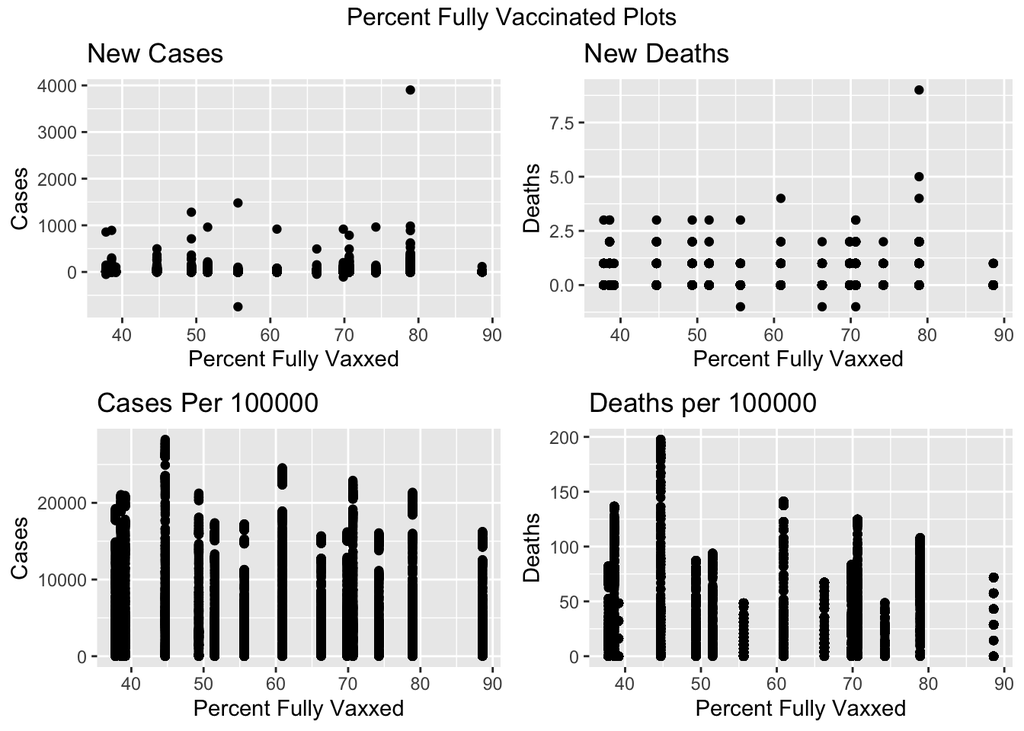

```r
vax1 <- ggplot(vt_cov, aes(x = PCT_fully_vaccinated, y = new_cases)) +
  geom_point() +
  labs(title = "New Cases", x = "Percent Fully Vaxxed", y = "Cases")
vax2 <- ggplot(vt_cov, aes(x = PCT_fully_vaccinated, y = new_deaths)) +
  geom_point() +
  labs(title = "New Deaths", x = "Percent Fully Vaxxed", y = "Deaths")
vax3 <- ggplot(vt_cov, aes(x = PCT_fully_vaccinated, y = cases_per_100000)) +
  geom_point() +
  labs(title = "Cases Per 100000", x = "Percent Fully Vaxxed", y = "Cases")
vax4 <- ggplot(vt_cov, aes(x = PCT_fully_vaccinated, y = deaths_per_100000)) +
  geom_point() +
  labs(title = "Deaths per 100000", x = "Percent Fully Vaxxed", y = "Deaths")
grid.arrange(vax1, vax2, vax3, vax4, top = "Percent Fully Vaccinated Plots")
```

Vaccination rates and peak new cases and new deaths, respectively, do not seem to have any strong correlations. Both cases per 100000 and deaths per 100000 seem to have a negative correlation with percent fully vaccinated. This indicates that as percent vaccinated increases, the number of cases and deaths per 100000 decreases. This loosely speaks to the postive effects of the Covid vaccine.

#### Mask Use vs Cases and Deaths

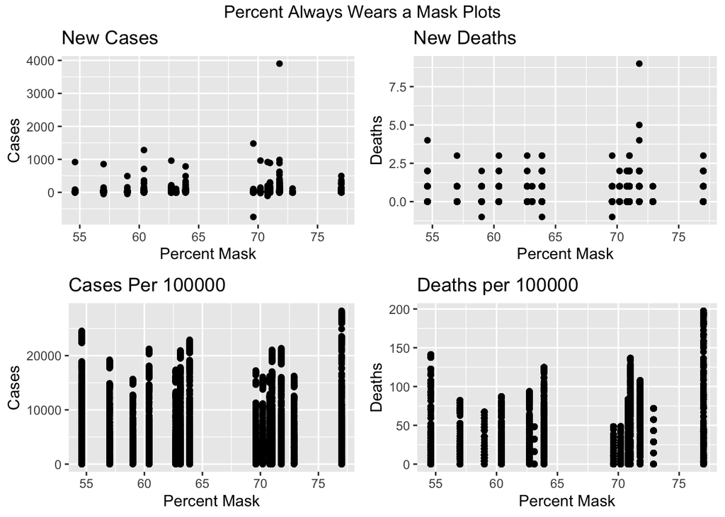

```r
mask1 <- ggplot(vt_cov, aes(x = PCT_always, y = new_cases)) +
  geom_point() +
  labs(title = "New Cases", x = "Percent Mask", y = "Cases")
mask2 <- ggplot(vt_cov, aes(x = PCT_always, y = new_deaths)) +
  geom_point() +
  labs(title = "New Deaths", x = "Percent Mask", y = "Deaths")
mask3 <- ggplot(vt_cov, aes(x = PCT_always, y = cases_per_100000)) +
  geom_point() +
  labs(title = "Cases Per 100000", x = "Percent Mask", y = "Cases")
mask4 <- ggplot(vt_cov, aes(x = PCT_always, y = deaths_per_100000)) +
  geom_point() +
  labs(title = "Deaths per 100000", x = "Percent Mask", y = "Deaths")
grid.arrange(mask1, mask2, mask3, mask4, top = "Percent Always Wears a Mask Plots")
```

Percent of the population that claims they always wear a mask does not seem to have a strong correlation with any of the outcome variables here. This is surprising because we would have expected higher mask use to relate to lower case numbers.

#### Household Income vs Cases and Deaths

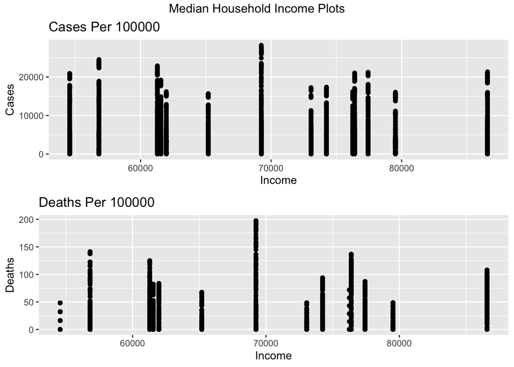

```r
inc1 <- ggplot(vt_cov, aes(x = Median_Household_Income_2022, y = cases_per_100000)) +
  geom_point() +
  labs(title = "Cases Per 100000", x = "Income", y = "Cases")
inc2 <- ggplot(vt_cov, aes(x = Median_Household_Income_2022, y = deaths_per_100000)) +
  geom_point() +
  labs(title = "Deaths Per 100000", x = "Income", y = "Deaths")
grid.arrange(inc1, inc2, nrow = 2, top = "Median Household Income Plots")
```

Median household income and deaths per 100000 seem to have a slight negative relation, with an unexpected peak at around $70,000. This would mean as income increases, deaths decrease. This could make sense as higher income households might have been able to better afford staying indoors and isolated during the pandemic.

#### Education Level vs Cases and Deaths

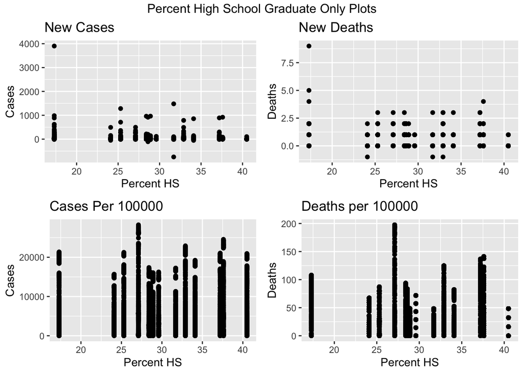

```r
edu1 <- ggplot(vt_cov, aes(x = PCT_HS_graduate, y = new_cases)) +
  geom_point() +
  labs(title = "New Cases", x = "Percent HS", y = "Cases")
edu2 <- ggplot(vt_cov, aes(x = PCT_HS_graduate, y = new_deaths)) +
  geom_point() +
  labs(title = "New Deaths", x = "Percent HS", y = "Deaths")
edu3 <- ggplot(vt_cov, aes(x = PCT_HS_graduate, y = cases_per_100000)) +
  geom_point() +
  labs(title = "Cases Per 100000", x = "Percent HS", y = "Cases")
edu4 <- ggplot(vt_cov, aes(x = PCT_HS_graduate, y = deaths_per_100000)) +
  geom_point() +
  labs(title = "Deaths per 100000", x = "Percent HS", y = "Deaths")
grid.arrange(edu1, edu2, edu3, edu4, top = "Percent High School Graduate Only Plots")
```

Again, here it is interesting to see that there doesn’t appear to be any strong correlation between the outcome and explanatory variables. This indicates that the percent of only high school graduates did not affect the Covid case and death data.

## Step 5 - Cases and Deaths in Depth

### Linear Regression

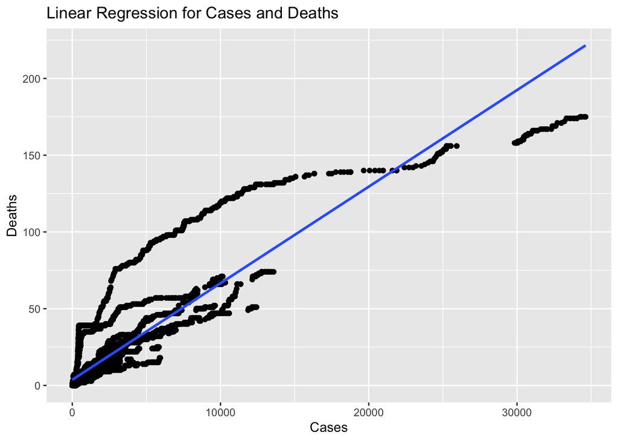

```r
ggplot(vt_cov, aes(x = cases, y = deaths)) +
  geom_point() +
  geom_smooth(method = "lm", se = FALSE) +
  labs(title = "Linear Regression for Cases and Deaths", x = "Cases", y = "Deaths")
```

```r
cd_lm <- lm(formula = deaths ~ cases, data = vt_cov)
get_regression_table(cd_lm)
```

| term | estimate | std_error | statistic | p_value | lower_ci | upper_ci |
| --- | --- | --- | --- | --- | --- | --- |
| intercept | 3.678 | 0.142 | 25.964 | 0 | 3.400 | 3.956 |
| cases | 0.006 | 0.000 | 202.117 | 0 | 0.006 | 0.006 |

As we can clearly see by the blue regression line, there is a positive correlation between cases and deaths. The estimate is positive and the standard error and p-value are both very small. Altogether, this indicates that our result is statistically significant, meaning that there is evidence of a positive correlation between cases and deaths. This is an expected result because in general, as cases increase, deaths will naturally increase as well.

### Hypothesis Test

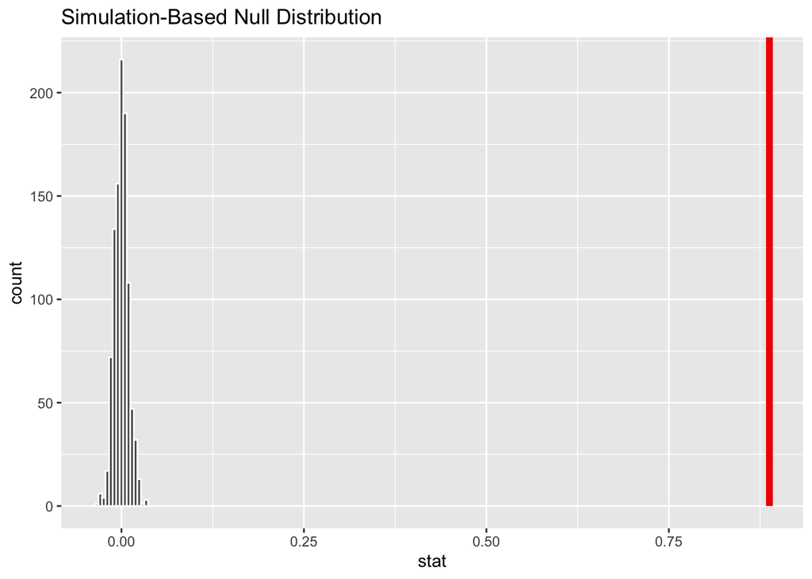

```r
cd_obs_stat <- cor(vt_cov$cases, vt_cov$deaths)

cd_distribution <- vt_cov %>%
  specify(response = deaths, explanatory = cases) %>%
  hypothesise(null = "independence") %>%
  generate(reps = 1000, type = "permute") %>%
  calculate(stat = "correlation")

visualise(cd_distribution) +
  shade_p_value(obs_stat = cd_obs_stat, direction = "right")
```

```r
cd_distribution %>%
  get_p_value(obs_stat = cd_obs_stat, direction = "right")
```

| p_value |
| --- |
| 0 |

To further confirm our result of a positive correlation between cases and deaths, we ran a hypothesis test. The null hypothesis being that there is no correlation between cases and deaths. The alternative hypothesis being that the correlation coefficient of cases and deaths is positive. Formally: $H_0: \rho = 0$ and $H_A: \rho > 0$. The observed correlation coefficient between cases and deaths is $\hat{\rho} = 0.89$. This is a good indication of a strong, positive correlation. The red vertical line represents that observed correlation. As seen, there is no overlap between the observed value and the distribution under the null hypothesis. In addition, the calculated p-value is 0, which is less than our significance level of 0.05. Therefore, we are able to reject the null hypothesis. This is evidence that there is a strong, positive correlation between cases and deaths. Again, this is an expected result and our most basic investigation of variables.

## Step 6 - Mask Mandate in Depth

### Exploratory Plots

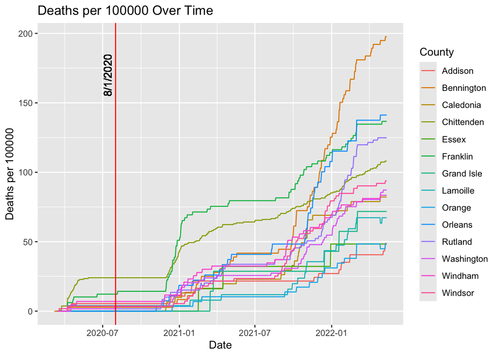

```r
mask_order_date <- as.Date("2020-08-01")

masks<-vt_cov%>%filter(date>=mask_order_date-28&date<mask_order_date)%>%
  mutate(masks=FALSE)%>%bind_rows(vt_cov%>%filter(date>mask_order_date+10&date<=mask_order_date+38)%>%mutate(masks=TRUE))

ggplot(vt_cov, aes(x = date, y = deaths_per_100000, group = county, color = county)) +
  geom_line() +
  geom_vline(xintercept = as.Date("2020-08-01"), color = "red") +
  geom_text(aes(x=as.Date(c("2020-08-01")),
    label="8/1/2020\n", y = 170),
    color="black", angle = 90) +
  labs(title = "Deaths per 100000 Over Time", x = "Date", y = "Deaths per 100000", color = "County")
```

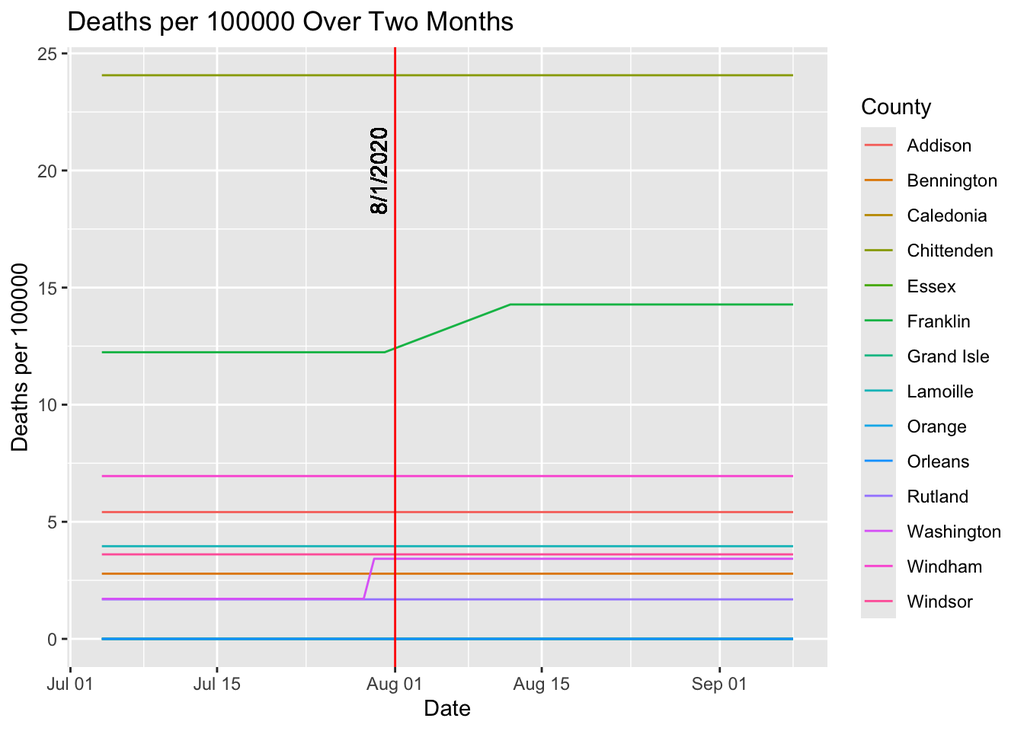

```r
ggplot(masks, aes(x = date, y = deaths_per_100000, group = county, color = county)) +
  geom_line() +
  geom_vline(xintercept = as.Date("2020-08-01"), color = "red") +
  geom_text(aes(x=as.Date(c("2020-08-01")),
    label="8/1/2020\n", y = 20),
    color="black", angle = 90) +
  labs(title = "Deaths per 100000 Over Two Months", x = "Date", y = "Deaths per 100000", color = "County")
```

### Hypothesis Test

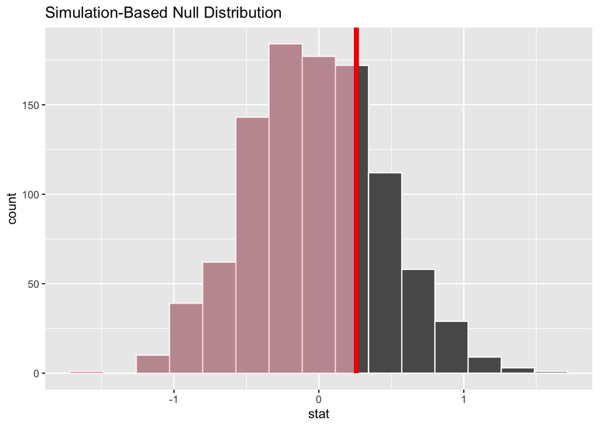

```r
m_a <-masks%>%ungroup()%>%filter(date>mask_order_date&date+10<=mask_order_date+38)%>%
  summarise(mean_deaths_100k=mean(deaths_per_100000))

m_b <-masks%>%ungroup()%>%filter(date>=mask_order_date-28&date<mask_order_date)%>%summarise(mean_deaths_100k=mean(deaths_per_100000))

mask_distribution <- masks %>%
  specify(formula = deaths_per_100000 ~ masks) %>%
  hypothesise(null = "independence") %>%
  generate(reps = 1000, type = "permute") %>%
  calculate(stat = "diff in means", order = c("TRUE", "FALSE"))
m_obs_diff <- m_a - m_b
visualise(mask_distribution) +
  shade_p_value(obs_stat = m_obs_diff, direction = "left")
```

```r
mask_distribution %>%
  get_p_value(obs_stat = m_obs_diff, direction = "left")
```

| p_value |
| --- |
| 0.72 |

To confirm the indications of the line plot, we ran a hypothesis test. The null hypothesis being that the difference in average deaths per 100,000 after and before the mask mandate was zero. The alternative hypothesis being that the average deaths per 100,000 after the mask mandate was less than the average deaths before. Formally: $H_0: \mu_A - \mu_B = 0$ and $H_A: \mu_A - \mu_B < 0$. The test statistic being the difference in average deaths per 100,000 after and before the mask mandate. The calculated observed value is $\hat{\mu}_A - \hat{\mu}_B = 0.26$. This is very close to zero, another indication that the difference is not significant. To prove this, the value is represented by the red vertical line. There is clearly a large overlap between the observed value and the distribution under the null hypothesis. In addition, the calculated p-value is around 0.722, which is far greater than our significance level of 0.05. Therefore, we fail to reject the null hypothesis. This means that there is evidence the difference in average deaths is not significant. In other words, the mask mandate did not have an effect on the average deaths. This is a surprising result because we would have expected the mask mandate to decrease cases and in turn decrease the average deaths.

### Confidence Interval

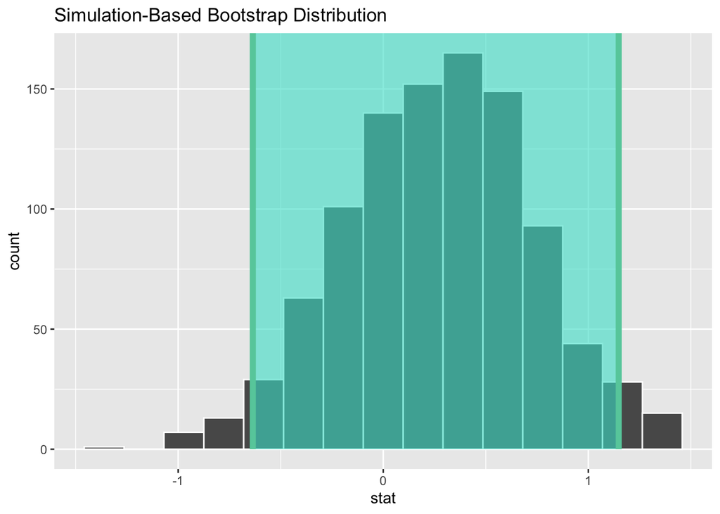

```r
mask_boot_dist <- masks %>%
  specify(formula = deaths_per_100000 ~ masks) %>%
  generate(reps = 1000, type = "bootstrap") %>%
  calculate(stat = "diff in means", order = c("TRUE", "FALSE"))

mask_ci <- mask_boot_dist %>%
  get_confidence_interval(type = "percentile", level = 0.95)

visualise(mask_boot_dist) +
  shade_confidence_interval(mask_ci)
```